# Sierra amphibians

Katie Munster

1/22/2022

## Overview

This report explores the counts of mountain yellow-legged frog (Rana muscosa) observed in the Sierra Nevada aquatic ecosystems. Amphibian abundance data were recorded by the Sierra Lakes Inventory Project from 1995-2002.

**Data citation:** Knapp, R.A., C. Pavelka, E.E. Hegeman, and T.C. Smith. 2020. The Sierra Lakes Inventory Project: Non-Native fish and community composition of lakes and ponds in the Sierra Nevada, California ver 2. Environmental Data Initiative. https://doi.org/10.6073/pasta/d835832d7fd00d9e4466e44eea87fab3.

```r
knitr::opts_chunk$set(echo = TRUE, message = FALSE, warning = FALSE)

library(tidyverse)
library(here)
library(patchwork)
library(cowplot)
library(lubridate)
```

## Data wrangling

Read in the data.

```r
# Read in data:
sierra_amphibians <- readxl::read_excel(here('data', 'sierra_amphibians.xlsx'))
```

## Total counts of adult, subadult, and tadpole yellow-legged frogs observed in the entire study region

#### Data wrangling

Clean the data to filter for adult, subadult, and tadpole Rana muscosa frogs.

```r
rana_muscosa <- sierra_amphibians %>%
  mutate(survey_date = ymd(survey_date)) %>% # convert the date to date format. Checked this with str(rana_muscosa$survey_date) in the console.
  mutate(year = year(survey_date)) %>% # create a column that only contains the year
  filter(amphibian_species == "RAMU") %>% # filter only for Rana muscosa species
  filter(amphibian_life_stage %in% c("SubAdult", "Tadpole", "Adult")) %>%  # exclude 'EggMass' level
  drop_na(amphibian_number)
```

Calculate the total observations of Rana muscosa frogs each year.

```r
rana_muscosa_counts <- rana_muscosa %>%
  group_by(amphibian_life_stage, year) %>% # Categorize the data by life stage and year
  summarize(rana_muscosa_count = sum(amphibian_number))
```

#### Data visualization

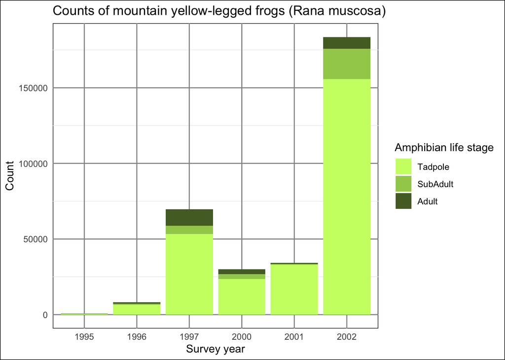

```r
# Data visualization:
plot1 <- ggplot(data = rana_muscosa_counts, aes(x = as.factor(year), y = rana_muscosa_count)) +
  geom_col(aes(fill = amphibian_life_stage)) +
  theme_minimal() +
  labs(x = "Survey year",
       y = "Count",
       title = "Counts of mountain yellow-legged frogs (Rana muscosa)",
       fill = "Amphibian life stage") +
  scale_fill_manual(values = c("Tadpole" = "darkolivegreen1",
                               "SubAdult" = "darkolivegreen3",
                               "Adult" = "darkolivegreen"),
                    limits = c("Tadpole", "SubAdult", "Adult")) +
  theme(plot.background = element_rect(fill = "white"),
        panel.background = element_rect(fill = "white"),
        panel.grid.major = element_line(color = "gray58"))

plot1
```

**Figure 1.** The count of mountain yellow-legged frog (Rana muscosa) in the Sierra Nevada aquatic ecosystems from the years 1995-2002. The counts are categorized by amphibian life stage (tadpole, subadult, or adult).

## Total counts of adult and subadult yellow-legged frogs observed in the 5 lakes with the greatest total observed counts

#### Data wrangling

Clean the data to filter for adult and subadult Rana muscosa frogs.

```r
rana_muscosa_by_lake <- sierra_amphibians %>%
  mutate(survey_date = ymd(survey_date)) %>% # convert the date to date format
  mutate(year = year(survey_date)) %>% # create a column that only contains the year
  filter(amphibian_species == "RAMU") %>% # filter only for Rana muscosa species
  filter(amphibian_life_stage %in% c("SubAdult", "Adult")) # exclude 'EggMass' and 'Tadpole' levels

rana_muscosa_by_lake$lake_id <- sub("^", "Lake ", rana_muscosa_by_lake$lake_id) # update lake_id column to add a label
```

Calculate the total observations of Rana muscosa frogs at each lake and determine the top five lakes with the greatest total observed counts.

```r
rana_muscosa_by_lake_counts <- rana_muscosa_by_lake %>%
  group_by(lake_id) %>% # Categorize the data by lake_id
  summarize(rana_muscosa_count = sum(amphibian_number)) %>%
  slice_max(rana_muscosa_count, n = 5) %>%
  arrange(desc(rana_muscosa_count))
```

#### Data visualization

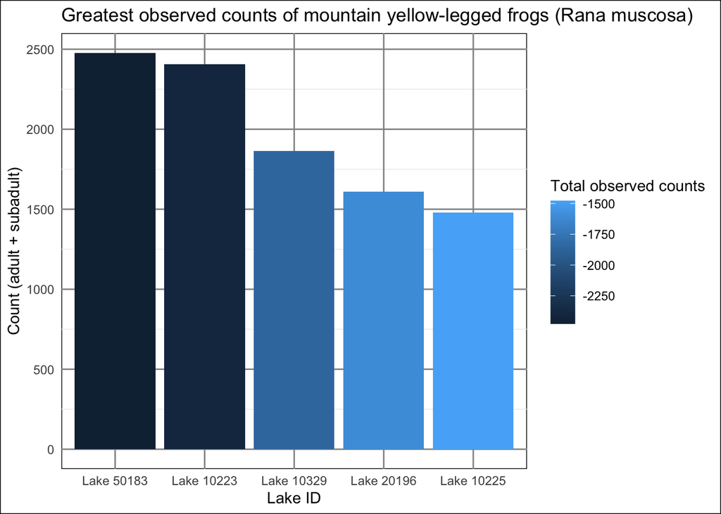

```r
# Data visualization:
plot2 <- ggplot(data = rana_muscosa_by_lake_counts, aes(x = fct_reorder(lake_id, -rana_muscosa_count), y = rana_muscosa_count)) +
  geom_col(aes(fill = -rana_muscosa_count)) +
  theme_minimal() +
  labs(x = "Lake ID",
       y = "Count (adult + subadult)",
       title = "Greatest observed counts of mountain yellow-legged frogs (Rana muscosa)",
       fill = "Total observed counts") +
  theme(plot.background = element_rect(fill = "white"),
        panel.background = element_rect(fill = "white"),
        panel.grid.major = element_line(color = "gray58"))

plot2
```

**Figure 2.** The top five Sierra Nevada lakes with the greatest total observed counts of mountain yellow-legged frog (Rana muscosa) for the years 1995-2002.

## Finalized compound figure

Combine the two graphs into a single compound figure.

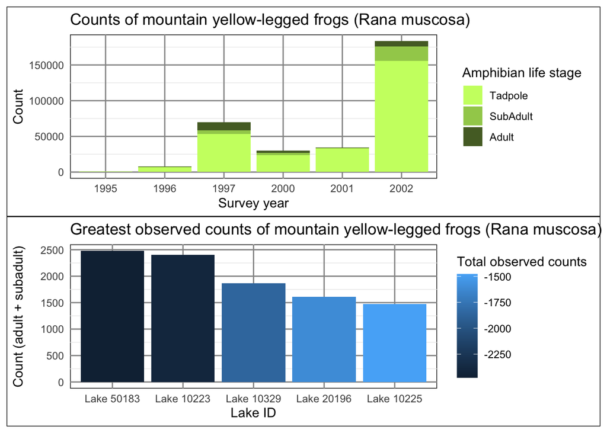

```r
plot1 / plot2
```

**Figure 3.** From 1995 to 2002, the observed counts of mountain yellow-legged frogs (Rana muscosa) in the tadpole life stage increased and the majority of observations were tadpoles, as compared to subadults and adults. Further analysis illustrates the top 5 lakes with the greatest total observed counts of subadult and adult mountain yellow-legged frogs recorded from 1995 to 2002.